# Simulating the 2019 CFB Season

2022-08-21

# What is this?

Which teams are most likely to win their conference in 2019? Make the playoff? Win the national championship?

This page displays the results from simulating all remaining games in the 2019 college football season 1000 times. These simulations come from an (adjusted) Elo model that I developed using historical game and play by data - the current iteration of the model uses historical game outcomes, team offensive and defensive efficiency metrics, and recruiting composites in order to estimate a team’s relative rating compared to other teams.

All data is from collegefootballdata.com. Any errors in the model are my own.

# 1 Predicting the 2019 Season

The following table shows each team’s rating, predicted record (for the regular season), and probabilities of making a bowl, winning a conference championship, making the playoff and/or winning the national championship.

These results are based on simulating the 2019 season **1000** times and finding the number of simulations in which a team achieved each outcome. These simulations are run after every week of the regular season - in the table below, click on the filter below ‘Week’ in the table below to examine the model’s predictions after each week of the season.

| Week | Conf | Team | Record | Rating | Win_Conf | Playoff | NC | Win_NC |
| --- | --- | --- | --- | --- | --- | --- | --- | --- |
| 0 | SEC | Alabama | 10.5 - 1.5 | 2032 | 0.370 | 0.596 | 0.380 | 0.245 |
| 0 | ACC | Clemson | 10.9 - 1.1 | 2003 | 0.597 | 0.701 | 0.407 | 0.231 |
| 0 | SEC | Georgia | 9.5 - 2.5 | 1919 | 0.236 | 0.325 | 0.160 | 0.090 |
| 0 | Big 12 | Oklahoma | 9.9 - 2.1 | 1879 | 0.424 | 0.352 | 0.163 | 0.075 |
| 0 | Big Ten | Ohio State | 9.7 - 2.3 | 1869 | 0.292 | 0.276 | 0.125 | 0.052 |
| 0 | SEC | LSU | 8.3 - 3.7 | 1838 | 0.079 | 0.133 | 0.063 | 0.030 |
| 0 | FBS Independents | Notre Dame | 9.2 - 2.8 | 1829 | 0.000 | 0.096 | 0.050 | 0.023 |
| 0 | Big 12 | Texas | 8.5 - 3.5 | 1781 | 0.224 | 0.125 | 0.062 | 0.024 |
| 0 | Big Ten | Michigan | 8.3 - 3.7 | 1779 | 0.163 | 0.128 | 0.066 | 0.025 |
| 0 | SEC | Auburn | 7.6 - 4.4 | 1778 | 0.057 | 0.078 | 0.040 | 0.022 |

[output cut: 120 more lines]

# 2 Playoff Probabilities

How has each team’s chances of making the playoff changed throughout the year? The following visualizations displays the probability of making the playoff for teams that have at any point achieved a probability of at least 1% of making the playoff.

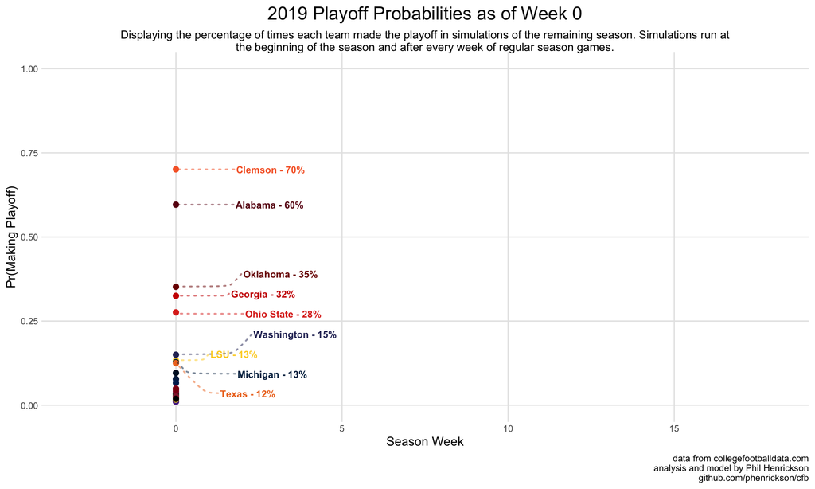

# 3 National Championship Probabilities

How has each team’s chances of winning the national championship changed throughout the year? The following visualizations displays the probability of winning the national championship by week for teams that have at any point achieved a probability of at least 1% of winning the NC.

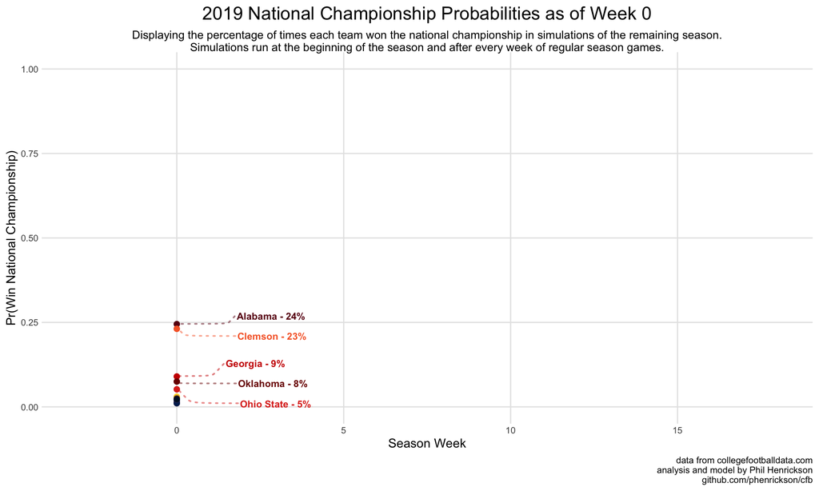

# 4 Conference Championship Probabilities

## 4.1 SEC

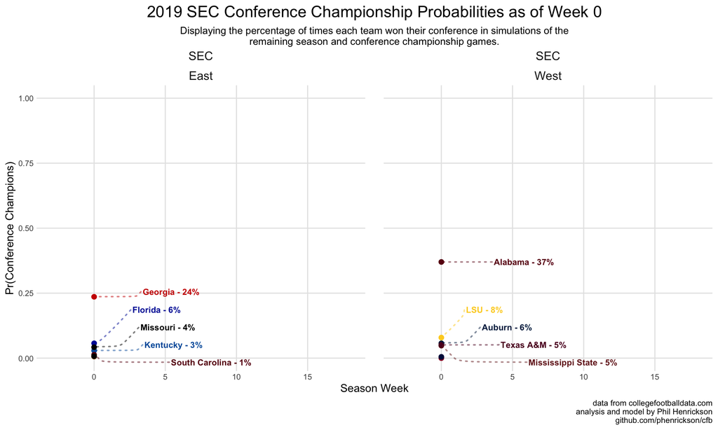

## 4.2 Big Ten

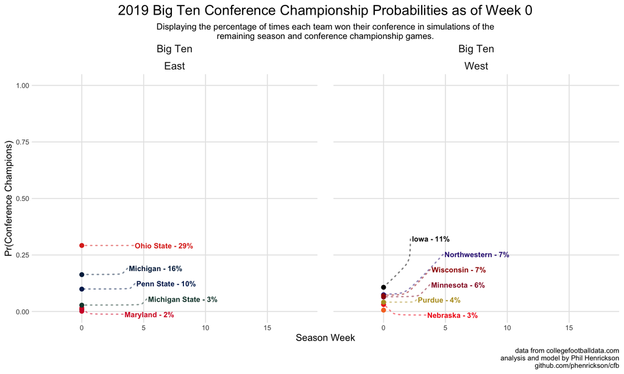

## 4.3 Big 12

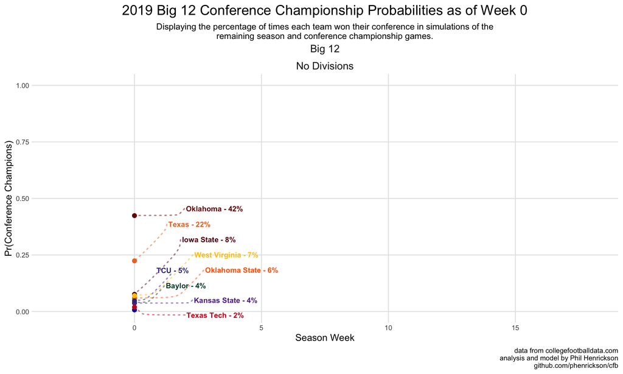

## 4.4 Pac-12

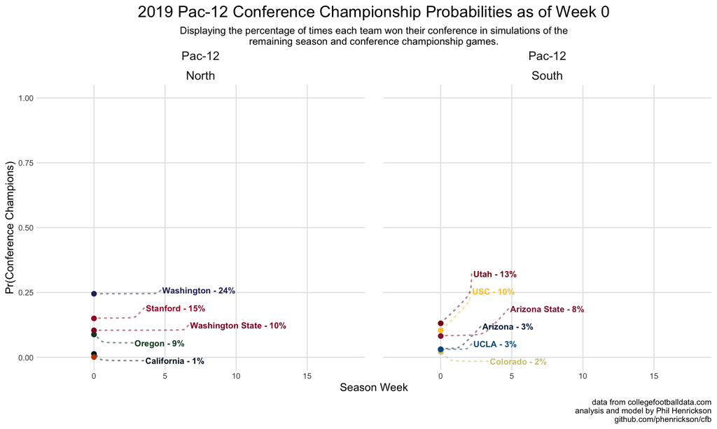

## 4.5 ACC

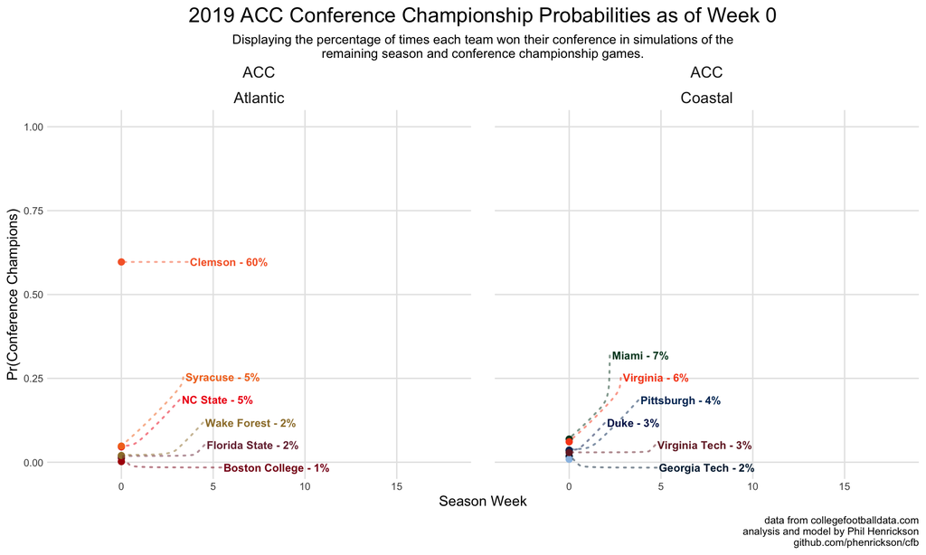

## 4.6 Mountain West

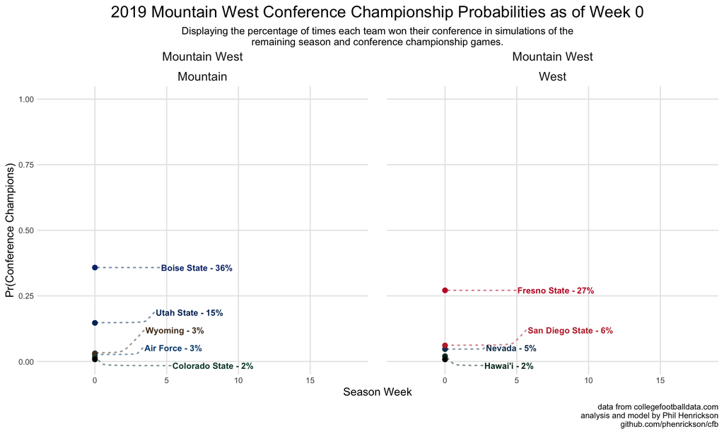

## 4.7 Mid-American

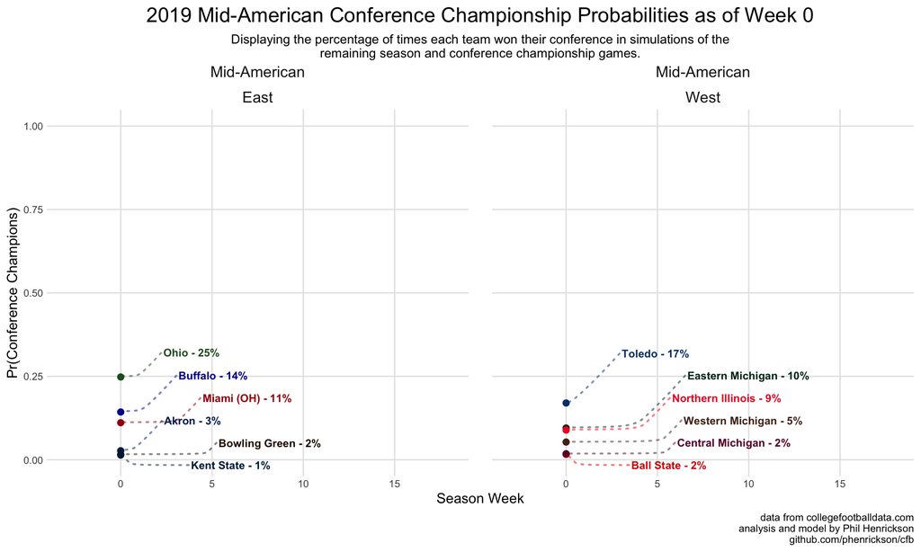

## 4.8 American Athletic

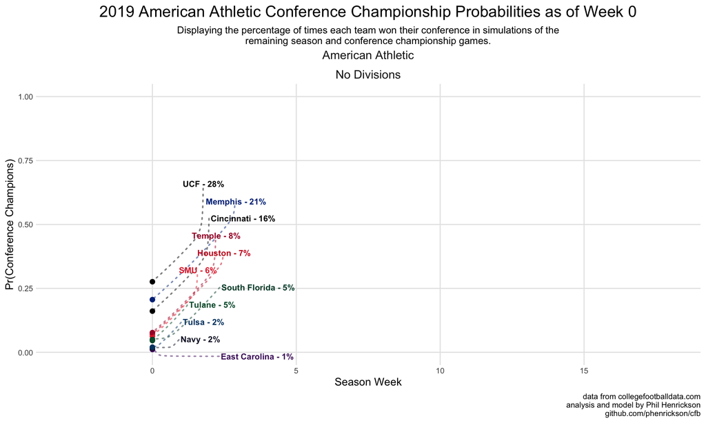

## 4.9 Sun Belt

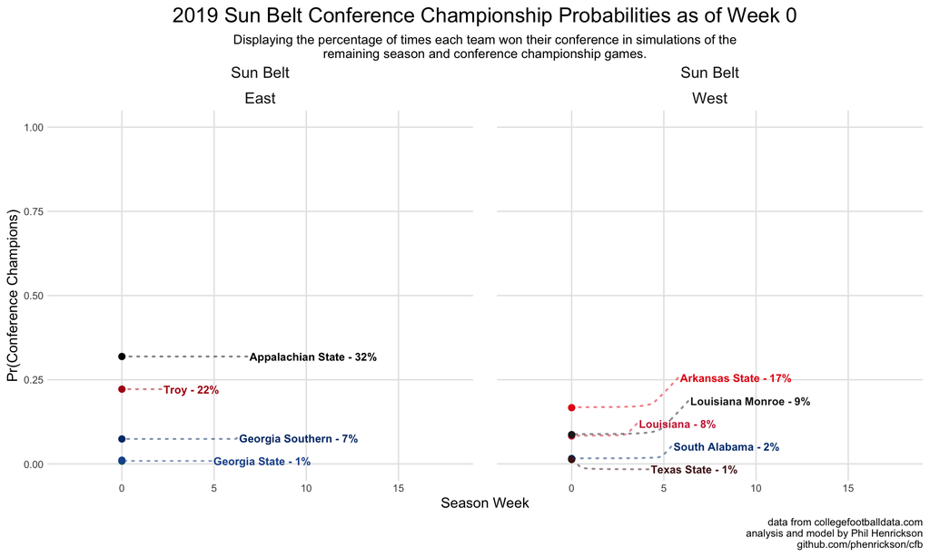

## 4.10 Conference USA

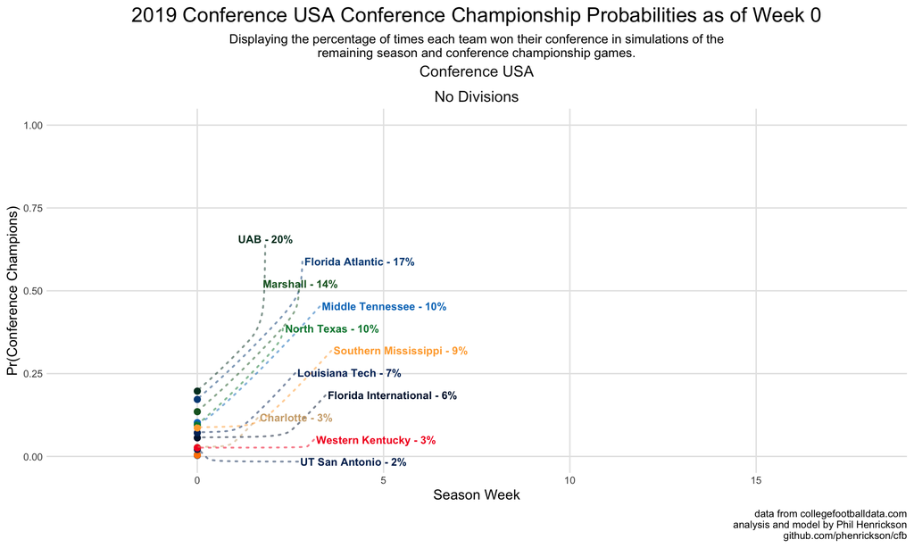